All examples from *How to Design and Report Experiments* by Andy Field & Graham Hole - ISBN 978-0-7619-7383-6

```python
import numpy as np
import pandas as pd
%matplotlib inline
import matplotlib
import matplotlib.pyplot as plt
```

# Descriptive Statistics

### Summarizing Data

- when summarizing data, we often calculate a summary or make a chart

```python
# observations of number of *amphetamine psychosis* per day

h = [10, 6, 7, 8, 9, 7, 10, 2, 6, 8,
     3, 9, 8, 10, 1, 5, 8, 4, 2, 9,
     10, 6, 7, 8, 9, 7, 10, 2, 6, 8,
     3, 9, 8, 10, 1, 5, 8, 4, 2, 9]
```

```python
h_sorted = h.copy()
h_sorted.sort()
```

```python
h_df = pd.DataFrame(h)
```

```python
h_sorted
```

```
[1,
 1,
 2,
 2,
 2,
 2,
 3,
 3,
 4,
 4,
 5,
 5,
 6,
 6,
 6,
 6,
 7,
 7,
 7,
 7,
 8,
 8,
 8,
 8,
 8,
 8,
 8,
 8,
 9,
 9,
 9,
 9,
 9,
 9,
 10,
 10,
 10,
 10,
 10,
 10]
```

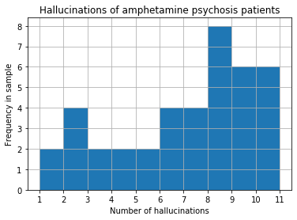

```python
h_hist = h_df.hist(bins=np.arange(min(h), max(h) + 2, 1.0), rwidth=1)
plt.title('Hallucinations of amphetamine psychosis patients')
plt.xlabel('Number of hallucinations')
plt.ylabel('Frequency in sample')
plt.xticks(range(min(h), max(h) + 2))
plt.show()
```

```python
# The mode: most frequent observation
h_df.mode()
```

|  | 0 |
| --- | --- |
| 0 | 8 |

```python
# The median: the center element
h_df.median()
```

```
0    7.5
dtype: float64
```

```python
# The mean
h_df.mean()
```

```
0    6.6
dtype: float64
```

The mean is defined as: $\mu = \overline{x} = \frac{\sum{x}}{n}$

```python
# The variance
h_df.var()
```

```
0    8.041026
dtype: float64
```

```python
h_df.var(ddof=0)
```

```
0    7.84
dtype: float64
```

```python
h_df.var(ddof=1)
```

```
0    8.041026
dtype: float64
```

```python
# The standard deviation
h_df.std()
```

```
0    2.83567
dtype: float64
```

The standard deviation is defined as:

$s = \sqrt{\frac{\sum{(x_i - \mu)}^2}{n}}$

$s = \sqrt{\frac{\sum{(x_i - \mu)}^2}{n - 1}}$

```python
# The standard error of the mean- for degrees of freedom 1
h_df.sem()
```

```
0    0.448359
dtype: float64
```

Statistics is most often communicated as one or a few numbers out of context. That is useless.

Instead, it should be communicated in a proper context:

- The number of units drunk before snogging Ben the Labrador was 10.00 units (SE=1.22)
- On average the Labradors had to be given 26.65 units of alcohol (SE=3.42) before they would play tonsil hockey with any of the blokes.

Or even better:

- Women needed substantially more units of alcohol (M=17.24, SE=2.53) than men (M=10.00, SE=1.22) before they would exchange saliva with a Labrador.
- Although Labradors would lick the participant's feet after very little alcohol (M=0.28, SE=0.11), they needed considerably more before they would do the tongue tango with the men (M=26.65, SE=3.42).

All examples from *How to Design and Report Experiments* by Andy Field & Graham Hole - ISBN 978-0-7619-7383-6